# Credit Card Users Churn Prediction

### Outlier detection & treatment.

```python
# Calculating - 25th & 75th perentile of all numerical columns
Q1 = data.select_dtypes(include=["float64", "int64"]).quantile(0.25)  # To find the 25th percentile
Q3 = data.select_dtypes(include=["float64", "int64"]).quantile(0.75)  # To find the 75th percentile

# Inter Quantile Range (75th perentile - 25th percentile)
IQR = Q3 - Q1

# Finding lower and upper bounds. All values outside these bounds are outliers
lower = (Q1 - 1.5 * IQR)
upper = (Q3 + 1.5 * IQR)
```

```python
# Display outliers count based on the upper & lower bounds
((data.select_dtypes(include=["float64", "int64"]) < lower) | (data.select_dtypes(include=["float64", "int64"]) > upper)).sum()
```

|  | 0 |
| --- | --- |
| Customer_Age | 2 |
| Dependent_count | 0 |
| Months_on_book | 386 |
| Total_Relationship_Count | 0 |
| Months_Inactive_12_mon | 331 |
| Contacts_Count_12_mon | 629 |
| Credit_Limit | 984 |
| Total_Revolving_Bal | 0 |
| Avg_Open_To_Buy | 963 |
| Total_Amt_Chng_Q4_Q1 | 396 |
| Total_Trans_Amt | 896 |
| Total_Trans_Ct | 2 |
| Total_Ct_Chng_Q4_Q1 | 394 |
| Avg_Utilization_Ratio | 0 |

**dtype:** int64

**Observations**

- As seen previously, we have some variables with high outliers, and the data distribution is significantly skewed or bimodal.
- After researching, found that Transformation and Scaling are the best options to handle those data set. (ref: [data-processing](https://lakefs.io/blog/data-preprocessing-in-machine-learning/))
- Doing further research based on [Transformation-Scaling-And-Normalization](https://medium.com/@isalindgren313/transformations-scaling-and-normalization-420b2be12300), decided to do Transformation and Scaling for below columns
- Log Transformation:
  - Credit_Limit
  - Avg_Open_To_Buy
  - Total_Trans_Amt
- Scale the above-transformed variables by Standard Scaling
  - Credit_Limit
  - Avg_Open_To_Buy
  - Total_Trans_Amt
- Use Robust Scaling for the below column
  - Total_Trans_Ct

```python
# Log transformation for skewed variables of training data
X_train['Credit_Limit_Log'] = np.log1p(X_train['Credit_Limit'])
X_train['Avg_Open_To_Buy_Log'] = np.log1p(X_train['Avg_Open_To_Buy'])
X_train['Total_Trans_Amt_Log'] = np.log1p(X_train['Total_Trans_Amt'])

# Initialize scalers
standard_scaler = StandardScaler()
robust_scaler = RobustScaler()

# Fit & Apply scaling to training set
X_train[['Credit_Limit_Scaled', 'Avg_Open_To_Buy_Scaled', 'Total_Trans_Amt_Scaled']] = standard_scaler.fit_transform(
        X_train[['Credit_Limit_Log', 'Avg_Open_To_Buy_Log', 'Total_Trans_Amt_Log']])

# Fit & Apply Robust Scaling to training set
X_train['Total_Trans_Ct_Scaled'] = robust_scaler.fit_transform(X_train[['Total_Trans_Ct']])
```

```python
# Log transformation for skewed variables of validation data
X_val['Credit_Limit_Log'] = np.log1p(X_val['Credit_Limit'])
X_val['Avg_Open_To_Buy_Log'] = np.log1p(X_val['Avg_Open_To_Buy'])
X_val['Total_Trans_Amt_Log'] = np.log1p(X_val['Total_Trans_Amt'])

# We only transform the data and will not fit again to avoid data leakage
# Apply scaling to validation set
X_val[['Credit_Limit_Scaled', 'Avg_Open_To_Buy_Scaled', 'Total_Trans_Amt_Scaled']] = standard_scaler.transform(
        X_val[['Credit_Limit_Log', 'Avg_Open_To_Buy_Log', 'Total_Trans_Amt_Log']])

# Apply Robust Scaling to validation set
X_val['Total_Trans_Ct_Scaled'] = robust_scaler.transform(X_val[['Total_Trans_Ct']])
```

```python
# Log transformation for skewed variables of test data
X_test['Credit_Limit_Log'] = np.log1p(X_test['Credit_Limit'])
X_test['Avg_Open_To_Buy_Log'] = np.log1p(X_test['Avg_Open_To_Buy'])
X_test['Total_Trans_Amt_Log'] = np.log1p(X_test['Total_Trans_Amt'])

# We only transform the data and will not fit again to avoid data leakage
# Apply scaling to test set
X_test[['Credit_Limit_Scaled', 'Avg_Open_To_Buy_Scaled', 'Total_Trans_Amt_Scaled']] = standard_scaler.transform(
        X_test[['Credit_Limit_Log', 'Avg_Open_To_Buy_Log', 'Total_Trans_Amt_Log']])

# Apply Robust Scaling to test set
X_test['Total_Trans_Ct_Scaled'] = robust_scaler.transform(X_test[['Total_Trans_Ct']])
```

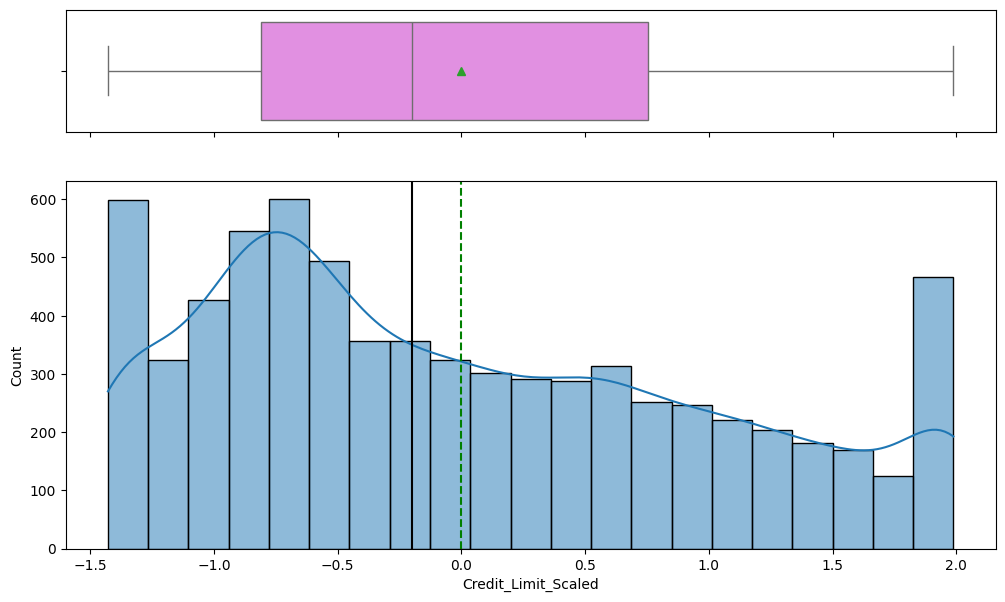

```python
# Display histogram & boxplot for Credit_Limit_Scaled of training set
histogram_boxplot(data=X_train, feature='Credit_Limit_Scaled', kde=True)
```

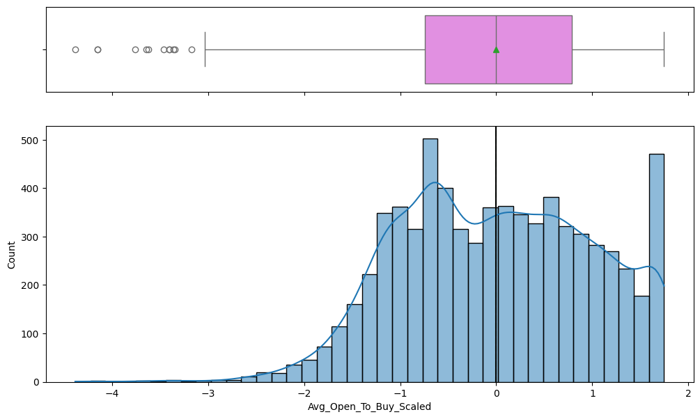

```python
# Display histogram & boxplot for Avg_Open_To_Buy_Scaled of training set
histogram_boxplot(data=X_train, feature='Avg_Open_To_Buy_Scaled', kde=True)
```

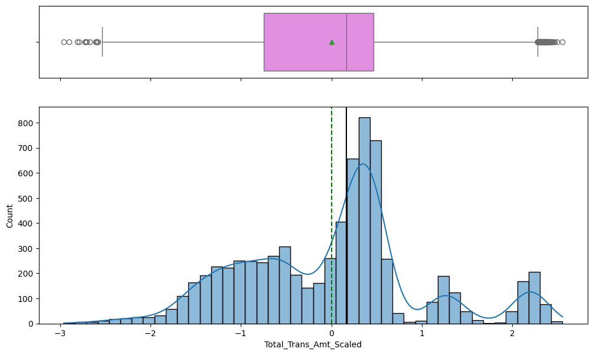

```python
# Display histogram & boxplot for Total_Trans_Amt_Scaled of training set
histogram_boxplot(data=X_train, feature='Total_Trans_Amt_Scaled', kde=True)
```

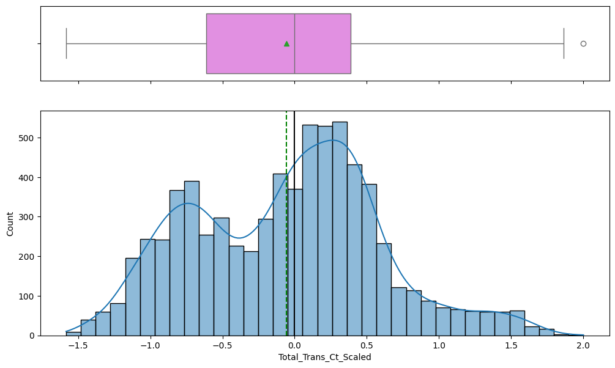

```python
# Display histogram & boxplot for Total_Trans_Ct_Scaled of training set
histogram_boxplot(data=X_train, feature='Total_Trans_Ct_Scaled', kde=True)
```

```python
# Droping unnecessary columns from Training Dataset
X_train = X_train.drop(['Credit_Limit', 'Avg_Open_To_Buy', 'Total_Trans_Amt',
                  'Credit_Limit_Log', 'Avg_Open_To_Buy_Log', 'Total_Trans_Amt_Log', 'Total_Trans_Ct'], axis=1)
```

```python
# Droping unnecessary columns from Validation Dataset
X_val = X_val.drop(['Credit_Limit', 'Avg_Open_To_Buy', 'Total_Trans_Amt',
                  'Credit_Limit_Log', 'Avg_Open_To_Buy_Log', 'Total_Trans_Amt_Log', 'Total_Trans_Ct'], axis=1)
```

```python
# Droping unnecessary columns from Testing Dataset
X_test = X_test.drop(['Credit_Limit', 'Avg_Open_To_Buy', 'Total_Trans_Amt',
                  'Credit_Limit_Log', 'Avg_Open_To_Buy_Log', 'Total_Trans_Amt_Log', 'Total_Trans_Ct'], axis=1)
```

```python
#Describing final training data-set to check.
X_train.describe().T
```

|  | count | mean | std | min | 25% | 50% | 75% | max |
| --- | --- | --- | --- | --- | --- | --- | --- | --- |
| Customer_Age | 7088.0 | 4.631377e+01 | 8.024498 | 26.000000 | 41.000000 | 46.000000 | 52.000000 | 73.000000 |
| Dependent_count | 7088.0 | 2.345937e+00 | 1.304915 | 0.000000 | 1.000000 | 2.000000 | 3.000000 | 5.000000 |
| Months_on_book | 7088.0 | 3.593623e+01 | 8.014232 | 13.000000 | 31.000000 | 36.000000 | 40.000000 | 56.000000 |
| Total_Relationship_Count | 7088.0 | 3.821106e+00 | 1.556661 | 1.000000 | 3.000000 | 4.000000 | 5.000000 | 6.000000 |
| Months_Inactive_12_mon | 7088.0 | 2.340717e+00 | 1.013258 | 0.000000 | 2.000000 | 2.000000 | 3.000000 | 6.000000 |
| Contacts_Count_12_mon | 7088.0 | 2.458663e+00 | 1.103370 | 0.000000 | 2.000000 | 2.000000 | 3.000000 | 6.000000 |
| Total_Revolving_Bal | 7088.0 | 1.160448e+03 | 814.767294 | 0.000000 | 282.500000 | 1282.500000 | 1782.000000 | 2517.000000 |
| Total_Amt_Chng_Q4_Q1 | 7088.0 | 7.587860e-01 | 0.218298 | 0.000000 | 0.629000 | 0.736000 | 0.859000 | 3.397000 |
| Total_Ct_Chng_Q4_Q1 | 7088.0 | 7.104218e-01 | 0.237084 | 0.000000 | 0.581000 | 0.700000 | 0.816000 | 3.714000 |
| Avg_Utilization_Ratio | 7088.0 | 2.772408e-01 | 0.277848 | 0.000000 | 0.019000 | 0.177000 | 0.507000 | 0.995000 |
| Gender_F | 7088.0 | 5.318849e-01 | 0.499018 | 0.000000 | 0.000000 | 1.000000 | 1.000000 | 1.000000 |
| Gender_M | 7088.0 | 4.681151e-01 | 0.499018 | 0.000000 | 0.000000 | 0.000000 | 1.000000 | 1.000000 |
| Education_Level_College | 7088.0 | 1.168172e-01 | 0.321225 | 0.000000 | 0.000000 | 0.000000 | 0.000000 | 1.000000 |
| Education_Level_Doctorate | 7088.0 | 5.149549e-02 | 0.221022 | 0.000000 | 0.000000 | 0.000000 | 0.000000 | 1.000000 |
| Education_Level_Graduate | 7088.0 | 3.608916e-01 | 0.480293 | 0.000000 | 0.000000 | 0.000000 | 1.000000 | 1.000000 |
| Education_Level_High School | 7088.0 | 2.340576e-01 | 0.423438 | 0.000000 | 0.000000 | 0.000000 | 0.000000 | 1.000000 |
| Education_Level_Post-Graduate | 7088.0 | 6.165350e-02 | 0.240542 | 0.000000 | 0.000000 | 0.000000 | 0.000000 | 1.000000 |
| Education_Level_Uneducated | 7088.0 | 1.750847e-01 | 0.380066 | 0.000000 | 0.000000 | 0.000000 | 0.000000 | 1.000000 |
| Marital_Status_Divorced | 7088.0 | 7.957111e-02 | 0.270647 | 0.000000 | 0.000000 | 0.000000 | 0.000000 | 1.000000 |
| Marital_Status_Married | 7088.0 | 5.282167e-01 | 0.499238 | 0.000000 | 0.000000 | 1.000000 | 1.000000 | 1.000000 |
| Marital_Status_Single | 7088.0 | 3.922122e-01 | 0.488278 | 0.000000 | 0.000000 | 0.000000 | 1.000000 | 1.000000 |
| Income_Category_5 | 7088.0 | 7.096501e-02 | 0.256785 | 0.000000 | 0.000000 | 0.000000 | 0.000000 | 1.000000 |
| Income_Category_2 | 7088.0 | 1.769187e-01 | 0.381627 | 0.000000 | 0.000000 | 0.000000 | 0.000000 | 1.000000 |
| Income_Category_3 | 7088.0 | 1.374153e-01 | 0.344310 | 0.000000 | 0.000000 | 0.000000 | 0.000000 | 1.000000 |
| Income_Category_4 | 7088.0 | 1.529345e-01 | 0.359950 | 0.000000 | 0.000000 | 0.000000 | 0.000000 | 1.000000 |
| Income_Category_1 | 7088.0 | 3.511569e-01 | 0.477366 | 0.000000 | 0.000000 | 0.000000 | 1.000000 | 1.000000 |
| Income_Category_0 | 7088.0 | 1.106095e-01 | 0.313670 | 0.000000 | 0.000000 | 0.000000 | 0.000000 | 1.000000 |
| Card_Category_Blue | 7088.0 | 9.341140e-01 | 0.248100 | 0.000000 | 1.000000 | 1.000000 | 1.000000 | 1.000000 |
| Card_Category_Gold | 7088.0 | 1.100451e-02 | 0.104331 | 0.000000 | 0.000000 | 0.000000 | 0.000000 | 1.000000 |
| Card_Category_Platinum | 7088.0 | 1.975169e-03 | 0.044402 | 0.000000 | 0.000000 | 0.000000 | 0.000000 | 1.000000 |
| Card_Category_Silver | 7088.0 | 5.290632e-02 | 0.223862 | 0.000000 | 0.000000 | 0.000000 | 0.000000 | 1.000000 |
| Credit_Limit_Scaled | 7088.0 | -1.131776e-15 | 1.000071 | -1.428146 | -0.810660 | -0.198305 | 0.756055 | 1.988153 |
| Avg_Open_To_Buy_Scaled | 7088.0 | 1.824475e-16 | 1.000071 | -4.384617 | -0.746900 | -0.006636 | 0.790053 | 1.746976 |
| Total_Trans_Amt_Scaled | 7088.0 | -1.435020e-15 | 1.000071 | -2.958642 | -0.746433 | 0.163383 | 0.464430 | 2.555355 |
| Total_Trans_Ct_Scaled | 7088.0 | -5.823614e-02 | 0.650653 | -1.583333 | -0.611111 | 0.000000 | 0.388889 | 2.000000 |

```python
X_train.info()
```

```
<class 'pandas.core.frame.DataFrame'>
Index: 7088 entries, 4124 to 4752
Data columns (total 35 columns):
 #   Column                         Non-Null Count  Dtype
---  ------                         --------------  -----
 0   Customer_Age                   7088 non-null   float64
 1   Dependent_count                7088 non-null   float64
 2   Months_on_book                 7088 non-null   float64
 3   Total_Relationship_Count       7088 non-null   float64
 4   Months_Inactive_12_mon         7088 non-null   float64
 5   Contacts_Count_12_mon          7088 non-null   float64
 6   Total_Revolving_Bal            7088 non-null   float64
 7   Total_Amt_Chng_Q4_Q1           7088 non-null   float64
 8   Total_Ct_Chng_Q4_Q1            7088 non-null   float64
 9   Avg_Utilization_Ratio          7088 non-null   float64
```

[output cut: 27 more lines]

```python
y_train.head()
```

|  | Attrition_Flag |
| --- | --- |
| 4124 | 0 |
| 4686 | 0 |
| 1276 | 0 |
| 6119 | 0 |
| 2253 | 0 |

**dtype:** category

```python
# Saving all the data sets so that we can read them back if required, later.
X_train.to_csv(path+'X_train')
X_val.to_csv(path+'X_val')
X_test.to_csv(path+'X_test')
y_train.to_csv(path+'y_train')
y_val.to_csv(path+'y_val')
y_test.to_csv(path+'y_test')
```

## Model Building

### Model evaluation criterion

**Model Evaluation Considarations**

*Identifying All Potential Churners:* Recall measures the model’s ability to capture all actual churners (those who truly intend to leave). A high recall means the model successfully identifies most customers at risk of leaving, allowing the bank to take preventive action to retain them.

Using Recall as a primary metric, supplemented by Precision and F1 Score, would give a balanced view:

- Recall: To ensure we are catching the majority of potential churners.
- Precision: To gauge the accuracy of predictions when the bank reaches out to prevent churn.
- F1 Score: For an overall measure that balances recall and precision.

This approach should help the bank focus on retaining as many potential churners as possible, while still keeping the cost of false positives under control.

### Functions for analysis

**Let's define a function to output different metrics (including recall) on the train and test set and a function to show confusion matrix so that we do not have to use the same code repetitively while evaluating models.**

```python
# Defining a function to compute different metrics to check performance of a classification model built using sklearn
def train_models_and_display_metrics(models, X_train, y_train, X_test, y_test, validationType):
  print("\n" "Model Performance:" "\n")
  for name, model in models:
      model.fit(X_train, y_train)
      accurecy = metrics.accuracy_score(y_train, model.predict(X_train))
      recall = metrics.recall_score(y_train, model.predict(X_train))
      precision = metrics.precision_score(y_train, model.predict(X_train))
      f1score = metrics.f1_score(y_train, model.predict(X_train))

      taccurecy = metrics.accuracy_score(y_test, model.predict(X_test))
      trecall = metrics.recall_score(y_test, model.predict(X_test))
      tprecision = metrics.precision_score(y_test, model.predict(X_test))
      tf1score = metrics.f1_score(y_test, model.predict(X_test))

      print("-" * 71)
      print("{}".format(name))
      print("-" * 71)
      df = pd.DataFrame([['TRAINING', accurecy, recall, precision, f1score],[validationType, taccurecy, trecall, tprecision, tf1score]], columns=[' ', 'Accuracy', 'Recall', 'Precision', 'F1'])
      print(df.to_string(index=False))
```

```python
# Importance of features in the tree building
def display_importance_of_features(model, feature_names):
  importances = model.feature_importances_
  df_imp = pd.DataFrame(importances, index=feature_names)
  df_imp = df_imp[df_imp[0] != 0]
  df_imp.columns = ['IMP']
  dp_imp = df_imp.sort_values(by='IMP', ignore_index=False, inplace=True)
  index_values = df_imp.index.values
  plt.figure(figsize=(10, 10))
  plt.title("Feature Importances")
  plt.barh(range(df_imp.shape[0]), df_imp['IMP'], color="red", align="center")
  plt.yticks(range(df_imp.shape[0]), index_values)
  plt.xlabel("Relative Importance")
  plt.show()
```

```python
# This function to display confusion matrix
def display_confusion_matrix(model, X, y):
  y_pred = model.predict(X)
  cm = metrics.confusion_matrix(y, y_pred)
  plt.figure(figsize=(7, 5))
  sns.heatmap(cm, annot=True, fmt="g")
  plt.xlabel("Predicted Values")
  plt.ylabel("Actual Values")
```

```python
# Read splitted datasets not needed when session is current.
# X_train=pd.read_csv(path+'X_train', index_col=0)
# X_val=pd.read_csv(path+'X_val', index_col=0)
# X_test=pd.read_csv(path+'X_test', index_col=0)
# y_train=pd.read_csv(path+'y_train', index_col=0)
# y_val=pd.read_csv(path+'y_val', index_col=0)
# y_test=pd.read_csv(path+'y_test', index_col=0)
```

### Model Building with original data

```python
models = []  # Empty list to store all the models
# Appending models into the list - with default parameters
models.append(("DecisionTreeClasifier", DecisionTreeClassifier(random_state=1)))
models.append(("BaggingDecisionTree", BaggingClassifier(random_state=1)))
models.append(("RandomForest", RandomForestClassifier(random_state=1)))

models.append(("AdaBoostClassifier", AdaBoostClassifier(random_state=1)))
models.append(("GradientBoostingClassifier", GradientBoostingClassifier(random_state=1)))
models.append(("XGBClassifier", XGBClassifier(random_state=1,eval_metric='logloss')))
train_models_and_display_metrics(models, X_train, y_train, X_val, y_val, 'VALIDATION')
```

```
Model Performance:

-----------------------------------------------------------------------
DecisionTreeClasifier
-----------------------------------------------------------------------
            Accuracy   Recall  Precision       F1
  TRAINING  1.000000 1.000000   1.000000 1.000000
VALIDATION  0.939434 0.820628   0.778723 0.799127
-----------------------------------------------------------------------
BaggingDecisionTree
-----------------------------------------------------------------------
            Accuracy   Recall  Precision       F1
  TRAINING  0.995909 0.979807   0.994652 0.987174
VALIDATION  0.957209 0.843049   0.862385 0.852608
-----------------------------------------------------------------------
RandomForest
-----------------------------------------------------------------------
            Accuracy   Recall  Precision       F1
  TRAINING   1.00000 1.000000   1.000000 1.000000
VALIDATION   0.94865 0.730942   0.900552 0.806931
-----------------------------------------------------------------------
AdaBoostClassifier
-----------------------------------------------------------------------
            Accuracy   Recall  Precision       F1
  TRAINING  0.957111 0.841089   0.886216 0.863063
VALIDATION  0.954575 0.829596   0.856481 0.842825
-----------------------------------------------------------------------
GradientBoostingClassifier
-----------------------------------------------------------------------
            Accuracy   Recall  Precision       F1
  TRAINING  0.976157 0.891133   0.957547 0.923147
VALIDATION  0.967742 0.878924   0.899083 0.888889
-----------------------------------------------------------------------
XGBClassifier
-----------------------------------------------------------------------
            Accuracy   Recall  Precision       F1
  TRAINING   1.00000 1.000000   1.000000 1.000000
VALIDATION   0.97235 0.892377   0.917051 0.904545
```

#### **Observations**

Based on the metrics, here’s an evaluation of each model’s performance

**Model for Further Tuning:**

Based on the metrics, XGBClassifier and GradientBoostingClassifier stand out as the best candidates for further tuning due to their high validation performance and balanced metrics:

XGBClassifier: Highest overall performance on the validation set with a strong recall and precision, making it the top choice for further improvement.

### Model Building with Oversampled data

```python
# Generating Synthetic samples using Over Sampling Technique
sm = SMOTE(sampling_strategy=1, k_neighbors=5, random_state=1)
X_train_over, y_train_over = sm.fit_resample(X_train, y_train)
```

```python
models = []  # Empty list to store all the models
# Appending models into the list - with default parameters
models.append(("DecisionTreeClasifier", DecisionTreeClassifier(random_state=1)))
models.append(("BaggingDecisionTree", BaggingClassifier(random_state=1)))
models.append(("RandomForest", RandomForestClassifier(random_state=1)))

models.append(("AdaBoostClassifier", AdaBoostClassifier(random_state=1)))
models.append(("GradientBoostingClassifier", GradientBoostingClassifier(random_state=1)))
models.append(("XGBClassifier", XGBClassifier(random_state=1,eval_metric='logloss')))
train_models_and_display_metrics(models, X_train_over, y_train_over, X_val, y_val, 'VALIDATION')
```

```
Model Performance:

-----------------------------------------------------------------------
DecisionTreeClasifier
-----------------------------------------------------------------------
            Accuracy   Recall  Precision       F1
  TRAINING  1.000000 1.000000    1.00000 1.000000
VALIDATION  0.926267 0.852018    0.70632 0.772358
-----------------------------------------------------------------------
BaggingDecisionTree
-----------------------------------------------------------------------
            Accuracy   Recall  Precision       F1
  TRAINING  0.998067 0.997479   0.998654 0.998066
VALIDATION  0.951942 0.887892   0.804878 0.844350
-----------------------------------------------------------------------
RandomForest
-----------------------------------------------------------------------
            Accuracy   Recall  Precision       F1
  TRAINING  1.000000 1.000000   1.000000 1.000000
VALIDATION  0.949967 0.798206   0.851675 0.824074
-----------------------------------------------------------------------
AdaBoostClassifier
-----------------------------------------------------------------------
            Accuracy   Recall  Precision       F1
  TRAINING  0.967137 0.967389   0.966902 0.967146
VALIDATION  0.951284 0.878924   0.806584 0.841202
-----------------------------------------------------------------------
GradientBoostingClassifier
-----------------------------------------------------------------------
            Accuracy   Recall  Precision       F1
  TRAINING  0.979913 0.978316   0.981450 0.979880
VALIDATION  0.963792 0.928251   0.841463 0.882729
-----------------------------------------------------------------------
XGBClassifier
-----------------------------------------------------------------------
            Accuracy  Recall  Precision       F1
  TRAINING  1.000000 1.00000   1.000000 1.000000
VALIDATION  0.974325 0.93722   0.893162 0.914661
```

#### **Observations**

**Model Evaluation with Oversampled Data:**

1. DecisionTreeClassifier:
- The recall improved slightly compared to the original model, but there’s still a noticeable decrease in precision. The overfitting seen in the training scores suggests the model could still struggle with generalization.
2. BaggingDecisionTree:
- The recall increased compared to the baseline, but precision dropped, which slightly lowered the F1-score. Bagging has improved recall, but the model could still benefit from further tuning to improve precision without compromising recall.
3. RandomForest:
- The recall improved, though it remains lower than other models. Precision is ok, but recall is still not as high as needed for identifying all churners, suggesting limited benefit from oversampling for this model.
4. AdaBoostClassifier:
- AdaBoost saw a significant improvement in recall, which aligns well with our objective of identifying churners. However, precision dropped.
5. GradientBoostingClassifier:
- Gradient Boosting demonstrated a substantial increase in recall with a moderate drop in precision, making it a strong candidate. The high recall aligns well with our goal, and the balance between recall and precision improves its robustness.
6. XGBClassifier:
- XGBoost performs well with the highest recall and a strong F1-score, indicating effective balance with minimal loss in precision. This model benefited from oversampling, making it the top-performing model for identifying churners.

**Model for Further Tuning:**

Based on the scores with the oversampled data, the XGBClassifier stands out as the best model to tune further. Its high recall, precision, and F1 score indicate it’s well-suited for identifying potential churners while maintaining a low rate of false positives.

### Model Building with Undersampled data

```python
# Random undersampler for under sampling the data
rus = RandomUnderSampler(random_state=1, sampling_strategy=1)
X_train_under, y_train_under = rus.fit_resample(X_train, y_train)
```

```python
models = []  # Empty list to store all the models
# Appending models into the list - with default parameters
models.append(("DecisionTreeClasifier", DecisionTreeClassifier(random_state=1)))
models.append(("BaggingDecisionTree", BaggingClassifier(random_state=1)))
models.append(("RandomForest", RandomForestClassifier(random_state=1)))

models.append(("AdaBoostClassifier", AdaBoostClassifier(random_state=1)))
models.append(("GradientBoostingClassifier", GradientBoostingClassifier(random_state=1)))
models.append(("XGBClassifier", XGBClassifier(random_state=1,eval_metric='logloss')))
train_models_and_display_metrics(models, X_train_under, y_train_under, X_val, y_val, 'VALIDATION')
```

```
Model Performance:

-----------------------------------------------------------------------
DecisionTreeClasifier
-----------------------------------------------------------------------
            Accuracy   Recall  Precision       F1
  TRAINING  1.000000 1.000000   1.000000 1.000000
VALIDATION  0.878868 0.869955   0.555874 0.678322
-----------------------------------------------------------------------
BaggingDecisionTree
-----------------------------------------------------------------------
            Accuracy   Recall  Precision       F1
  TRAINING  0.992976 0.987709   0.998225 0.992939
VALIDATION  0.922976 0.937220   0.669872 0.781308
-----------------------------------------------------------------------
RandomForest
-----------------------------------------------------------------------
            Accuracy   Recall  Precision       F1
  TRAINING  1.000000 1.000000    1.00000 1.000000
VALIDATION  0.935484 0.950673    0.70903 0.812261
-----------------------------------------------------------------------
AdaBoostClassifier
-----------------------------------------------------------------------
            Accuracy   Recall  Precision       F1
  TRAINING  0.945566 0.951712   0.940156 0.945899
VALIDATION  0.931534 0.955157   0.693811 0.803774
-----------------------------------------------------------------------
GradientBoostingClassifier
-----------------------------------------------------------------------
            Accuracy   Recall  Precision       F1
  TRAINING  0.976734 0.978051   0.975482 0.976765
VALIDATION  0.939434 0.959641   0.720539 0.823077
-----------------------------------------------------------------------
XGBClassifier
-----------------------------------------------------------------------
            Accuracy   Recall  Precision       F1
  TRAINING  1.000000 1.000000   1.000000 1.000000
VALIDATION  0.937459 0.959641   0.713333 0.818356
```

#### **Observations**

**Model Evaluation Summary with Undersampled Data:**

1. DecisionTreeClassifier:
- Recall remains relatively high, but precision has dropped significantly, resulting in a lower F1-score. The model may be capturing many churners but at the cost of identifying many non-churners as churners.
2. BaggingDecisionTree:
- Bagging helps maintain a high recall, but precision is still lower than desired, leading to a moderate F1-score. This model captures more churners than the single decision tree, but it appears precision could be further improved.
3. RandomForest:
- Random Forest performs better on recall with undersampling than with oversampling but suffers from reduced precision. The trade-off here is an acceptable increase in recall, but the precision loss lowers the F1-score.
4. AdaBoostClassifier:
- AdaBoost benefits from undersampling, showing a higher recall than in oversampling but at a cost in precision. The F1-score is still strong, making this model a viable option if high recall is the priority.
5. GradientBoostingClassifier:
- Gradient Boosting achieved high recall while maintaining a decent precision, resulting in an improved F1-score. The balance of high recall and acceptable precision makes it a strong candidate.
6. XGBClassifier:
- XGBoost achieves high recall and a relatively strong F1-score with undersampling, similar to Gradient Boosting. The model captures nearly all churners while managing precision better than most models..

**Model for Further Tuning:**

Undersampling improved recall across models, particularly for Gradient Boosting and XGBoost, while showing some trade-offs in precision. Given our objective of maximizing recall, both models are strong contenders, with Gradient Boosting slightly favored due to its better precision in this setup.

## HyperparameterTuning

### Models selected for Hyperparameter Tuning:

**Trained with Original Data:**

**Oversampled Data Models:**

- Model: XGBClassifier
- Reason: XGBClassifier with oversampling showed the best recall (93.7%) and a very strong F1-score (91.4%). The model benefited significantly from oversampling, capturing more churners while maintaining good precision, which aligns well with our target.

**Undersampled Data Models:**

- Model: GradientBoostingClassifier
- Reason: GradientBoostingClassifier on undersampled data achieved high recall (95.9%) with an F1-score of 82.3%. It demonstrated strong generalization and maintained a good balance between recall and precision, making it a strong choice for tuning.

### Tuning XGBClassifier with Original data

```python
# defining model
model_original_data = XGBClassifier(random_state=1,eval_metric='logloss')

# Parameter grid to pass in RandomSearchCV
param_grid={
    'n_estimators':np.arange(50,110,25),
    'scale_pos_weight':[1,2,5],
    'learning_rate':[0.01,0.1,0.05],
    'gamma':[1,3],
    'subsample':[0.7,0.9,1.0]
}
scorer = metrics.make_scorer(metrics.recall_score)
#Calling RandomizedSearchCV
randomized_cv = RandomizedSearchCV(estimator=model_original_data, param_distributions=param_grid, n_iter=10, n_jobs = -1, scoring=scorer, cv=5, random_state=1)

#Fitting parameters in RandomizedSearchCV
randomized_cv.fit(X_train,y_train)
```

```
RandomizedSearchCV(cv=5,
                   estimator=XGBClassifier(base_score=None, booster=None,
                                           callbacks=None,
                                           colsample_bylevel=None,
                                           colsample_bynode=None,
                                           colsample_bytree=None, device=None,
                                           early_stopping_rounds=None,
                                           enable_categorical=False,
                                           eval_metric='logloss',
                                           feature_types=None, gamma=None,
                                           grow_policy=None,
                                           importance_type=None,
                                           interaction_constraints=None,
                                           learning...
                                           monotone_constraints=None,
                                           multi_strategy=None,
                                           n_estimators=None, n_jobs=None,
                                           num_parallel_tree=None,
                                           random_state=1, ...),
                   n_jobs=-1,
                   param_distributions={'gamma': [1, 3],
                                        'learning_rate': [0.01, 0.1, 0.05],
                                        'n_estimators': array([ 50,  75, 100]),
                                        'scale_pos_weight': [1, 2, 5],
                                        'subsample': [0.7, 0.9, 1.0]},
                   random_state=1,
                   scoring=make_scorer(recall_score, response_method='predict'))
```

```python
print("Best parameters are {} with CV score={}:" .format(randomized_cv.best_params_,randomized_cv.best_score_))
model_original_data_tuned  = randomized_cv.best_estimator_
```

```
Best parameters are {'subsample': 0.7, 'scale_pos_weight': 5, 'n_estimators': 100, 'learning_rate': 0.05, 'gamma': 3} with CV score=0.9271350181621456:
```

```python
tuned_models = []
tuned_models.append(("Tuned - XGBClassifier - on Original Data", model_original_data_tuned))
train_models_and_display_metrics(tuned_models, X_train, y_train, X_val, y_val, "VALIDATION")
```

```
Model Performance:

-----------------------------------------------------------------------
Tuned - XGBClassifier - on Original Data
-----------------------------------------------------------------------
            Accuracy   Recall  Precision       F1
  TRAINING  0.980672 0.999122   0.893250 0.943224
VALIDATION  0.959842 0.946188   0.811538 0.873706
```

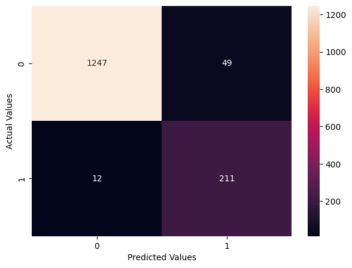

```python
# Confusion Matrix for validation set
display_confusion_matrix(model_original_data_tuned, X_val, y_val)
```

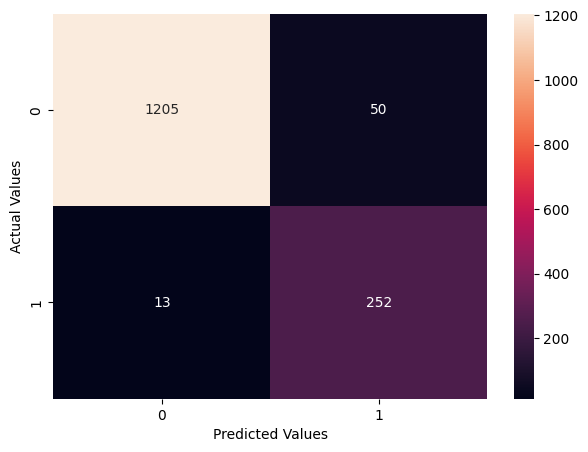

```python
# Confusion Matrix for test set
display_confusion_matrix(model_original_data_tuned, X_test, y_test)
```

[figure not shown]

```python
display_importance_of_features(model_original_data_tuned, X_train.columns)
```

#### Evaluation of Tuned XGBClassifier on Original Data

**Training Performance:**

**Validation Performance:**

**Summary**

The high validation recall shows that the model generalizes well and captures nearly all churners. The precision drop in the validation set is ok, given the high recall, which aligns with the objective of identifying all potential churners.

### Tuning XGBClassifier with Oversampled data

```python
model_oversampled_data = XGBClassifier(random_state=1,eval_metric='logloss')

# Parameter grid to pass in RandomSearchCV
param_grid={
    'n_estimators':np.arange(50,110,25),
    'scale_pos_weight':[1,2,5],
    'learning_rate':[0.01,0.1,0.05],
    'gamma':[1,3],
    'subsample':[0.7,0.9,1.0]
}
scorer = metrics.make_scorer(metrics.recall_score)
#Calling RandomizedSearchCV
randomized_cv = RandomizedSearchCV(estimator=model_oversampled_data, param_distributions=param_grid, n_iter=10, n_jobs = -1, scoring=scorer, cv=5, random_state=1)

#Fitting parameters in RandomizedSearchCV
randomized_cv.fit(X_train_over,y_train_over)
```

```
RandomizedSearchCV(cv=5,
                   estimator=XGBClassifier(base_score=None, booster=None,
                                           callbacks=None,
                                           colsample_bylevel=None,
                                           colsample_bynode=None,
                                           colsample_bytree=None, device=None,
                                           early_stopping_rounds=None,
                                           enable_categorical=False,
                                           eval_metric='logloss',
                                           feature_types=None, gamma=None,
                                           grow_policy=None,
                                           importance_type=None,
                                           interaction_constraints=None,
                                           learning...
                                           monotone_constraints=None,
                                           multi_strategy=None,
                                           n_estimators=None, n_jobs=None,
                                           num_parallel_tree=None,
                                           random_state=1, ...),
                   n_jobs=-1,
                   param_distributions={'gamma': [1, 3],
                                        'learning_rate': [0.01, 0.1, 0.05],
                                        'n_estimators': array([ 50,  75, 100]),
                                        'scale_pos_weight': [1, 2, 5],
                                        'subsample': [0.7, 0.9, 1.0]},
                   random_state=1,
                   scoring=make_scorer(recall_score, response_method='predict'))
```

```python
print("Best parameters are {} with CV score={}:" .format(randomized_cv.best_params_,randomized_cv.best_score_))
model_oversampled_data_tuned  = randomized_cv.best_estimator_
```

```
Best parameters are {'subsample': 1.0, 'scale_pos_weight': 5, 'n_estimators': 50, 'learning_rate': 0.05, 'gamma': 3} with CV score=0.9855455117286613:
```

```python
tuned_models = []
tuned_models.append(("Tuned - XGBClassifier - on oversampled Data", model_oversampled_data_tuned))
train_models_and_display_metrics(tuned_models, X_train_over, y_train_over, X_val, y_val, 'VALIDATION')
```

```
Model Performance:

-----------------------------------------------------------------------
Tuned - XGBClassifier - on oversampled Data
-----------------------------------------------------------------------
            Accuracy   Recall  Precision       F1
  TRAINING  0.950664 0.998487   0.911322 0.952916
VALIDATION  0.887426 0.968610   0.568421 0.716418
```

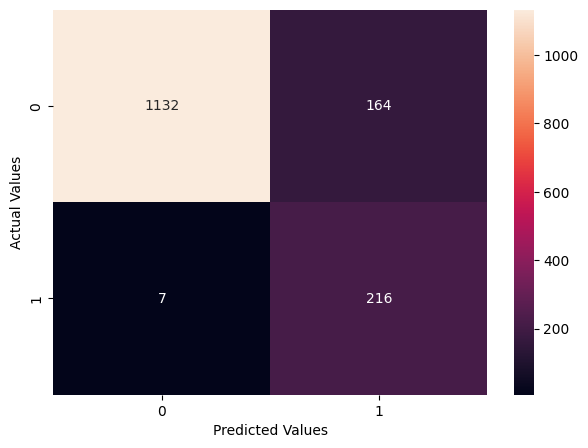

```python
display_confusion_matrix(model_oversampled_data_tuned, X_val, y_val)
```

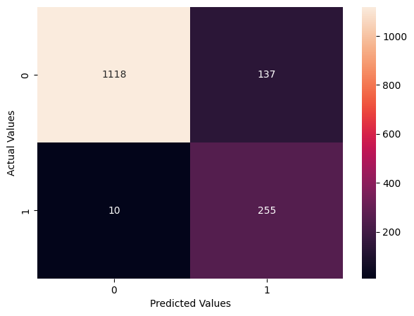

```python
display_confusion_matrix(model_oversampled_data_tuned, X_test, y_test)
```

[figure not shown]

```python
display_importance_of_features(model_oversampled_data_tuned, X_val.columns)
```

#### Evaluation of Tuned XGBClassifier on Oversampled Data

**Training Performance:**

The training set performance shows extremely high recall (99.9%) with strong precision (91.1%) and an F1-score of 95.2%, indicating the model captures nearly all churners while maintaining good accuracy.

**Validation Performance:**

- Recall: 96.86% – The model’s recall is high on the validation set, effectively capturing almost all potential churners.
- Precision: 56.84% – Precision has dropped notably, indicating an increase in false positives (non-churners misclassified as churners).
- F1-Score: 71.6% – Lower F1-score due to the decrease in precision, but still acceptable given the high recall.

**Summary**

The model achieves excellent recall on both training and validation sets, which aligns well with our goal of identifying as many churners as possible. The lower precision on the validation set means more false positives, which could lead to additional follow-up efforts for customers incorrectly flagged as churners.

### Tuning GradientBoostingClassifier with Undersampled data

```python
# Checking all the available hyper parameters for - GradientBoostingClassifier.
GradientBoostingClassifier().get_params()
```

```
{'ccp_alpha': 0.0,
 'criterion': 'friedman_mse',
 'init': None,
 'learning_rate': 0.1,
 'loss': 'log_loss',
 'max_depth': 3,
 'max_features': None,
 'max_leaf_nodes': None,
 'min_impurity_decrease': 0.0,
 'min_samples_leaf': 1,
 'min_samples_split': 2,
 'min_weight_fraction_leaf': 0.0,
 'n_estimators': 100,
 'n_iter_no_change': None,
 'random_state': None,
 'subsample': 1.0,
 'tol': 0.0001,
 'validation_fraction': 0.1,
 'verbose': 0,
 'warm_start': False}
```

```python
# defining model
model_undersampled_data = GradientBoostingClassifier(random_state=1)

# Parameter grid to pass in RandomSearchCV
param_grid = {
  "init": [None, AdaBoostClassifier(random_state=1),DecisionTreeClassifier(random_state=1)],
  "n_estimators": np.arange(50,110,25),
  "learning_rate": [0.01,0.1,0.05],
  "subsample":[0.7,0.9],
  "max_features":[0.5,0.7,1],
}
#Calling RandomizedSearchCV
randomized_cv = RandomizedSearchCV(estimator=model_undersampled_data, param_distributions=param_grid, n_iter=10, n_jobs = -1, scoring=scorer, cv=5, random_state=1)

#Fitting parameters in RandomizedSearchCV
randomized_cv.fit(X_train_under,y_train_under)
```

```
RandomizedSearchCV(cv=5, estimator=GradientBoostingClassifier(random_state=1),
                   n_jobs=-1,
                   param_distributions={'init': [None,
                                                 AdaBoostClassifier(random_state=1),
                                                 DecisionTreeClassifier(random_state=1)],
                                        'learning_rate': [0.01, 0.1, 0.05],
                                        'max_features': [0.5, 0.7, 1],
                                        'n_estimators': array([ 50,  75, 100]),
                                        'subsample': [0.7, 0.9]},
                   random_state=1,
                   scoring=make_scorer(recall_score, response_method='predict'))
```

```python
print("Best parameters are {} with CV score={}:" .format(randomized_cv.best_params_,randomized_cv.best_score_))
model_undersampled_data_tuned = randomized_cv.best_estimator_
```

```
Best parameters are {'subsample': 0.9, 'n_estimators': 100, 'max_features': 0.5, 'learning_rate': 0.1, 'init': AdaBoostClassifier(random_state=1)} with CV score=0.9499652214236031:
```

```python
tuned_models = []
tuned_models.append(("Tuned - GradiantClassifier - on undersampled Data", model_undersampled_data_tuned))
train_models_and_display_metrics(tuned_models, X_train_under, y_train_under, X_val, y_val, 'VALIDATION')
```

```
Model Performance:

-----------------------------------------------------------------------
Tuned - GradiantClassifier - on undersampled Data
-----------------------------------------------------------------------
            Accuracy   Recall  Precision       F1
  TRAINING  0.974100 0.977173   0.971204 0.974179
VALIDATION  0.946675 0.946188   0.753571 0.838966
```

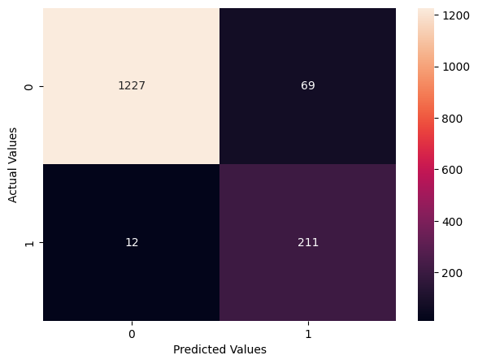

```python
display_confusion_matrix(model_undersampled_data_tuned, X_val, y_val)
```

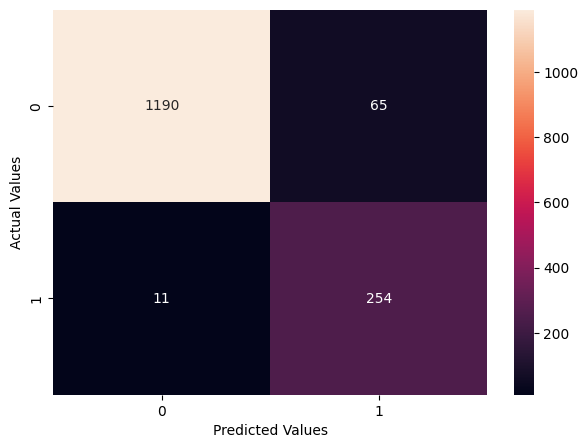

```python
display_confusion_matrix(model_undersampled_data_tuned, X_test, y_test)
```

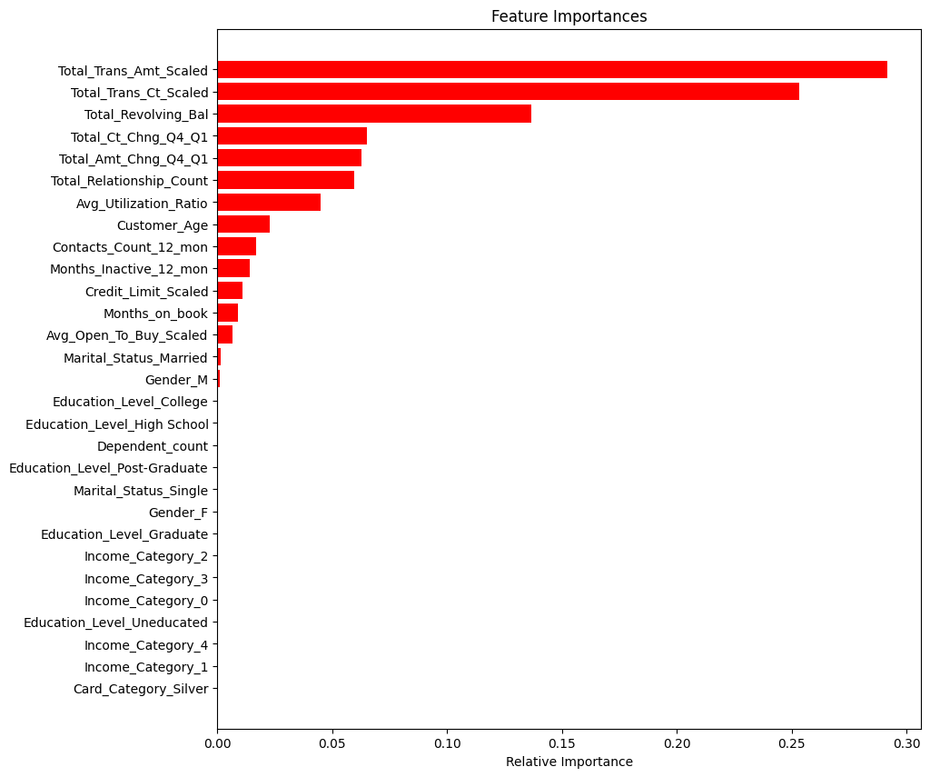

```python
display_importance_of_features(model_undersampled_data_tuned, X_val.columns)
```

#### Evaluation of Tuned GradientBoostingClassifier on Undersampled Data

**Training Performance:**

**Validation Performance:**

- Recall: 94.61% – The model maintains high recall on the validation set, capturing most churners.
- Precision: 75.3% – Precision is lower, meaning there are more false positives compared to the training set.
- F1-Score: 83.8% – The F1-score reflects a good balance on the validation set, though it is impacted by the drop in precision.

**Summary**

The model achieves high recall on both training and validation sets, making it highly effective for identifying churners. The decrease in validation precision suggests that the model is identifying some non-churners as churners, which could increase false positives.

## Model Comparison and Final Model Selection

### Model Comparison

- XGBClassifier (Original Data):

  **Strengths:** Balanced performance with high recall and precision, making it well-suited for identifying churners while keeping false positives low.
- XGBClassifier (Oversampled Data):

  **Strengths:** Highest recall across models, capturing nearly all potential churners, ideal if the main objective is to maximize recall even with some trade-off in precision.
- GradientBoostingClassifier (Undersampled Data):

  **Strengths:** High recall with improved precision over the oversampled model, offering a strong balance that reduces false positives while effectively identifying churners.

*Each model excels in different areas depending on the emphasis between recall and precision.*

**Summary of the Tuned Models performance on validation data**

| Model | Validation Recall | Validation Precision | Validation F1-Score | Strength |
| --- | --- | --- | --- | --- |
| XGBClassifier (Original Data) | 94.6% | 81.1% | 87.3% | Balanced recall and precision |
| XGBClassifier (Oversampled) | 96.8% | 56.8% | 71.6% | Maximum recall, lower precision |
| GradientBoosting (Undersampled) | 94.6% | 75.3% | 83.8% | High recall, better precision trade-off |

### Final model selection

Given that maximizing recall for identifying potential churners is the primary goal, then the XGBClassifier trained on the oversampled data seems the best.

Here’s why this model aligns best with a recall-focused objective:

Highest Recall: This model achieved a validation recall of 96.8%, which is the highest among all models. It will identify potential churners effectively.

- Tolerance for Lower Precision: While precision is lower (56.8%), this is acceptable in a scenario where the cost of missing a churner is much higher than the cost of a false positive.
- Reliability in Identifying Churners: The oversampling technique enhances the model’s sensitivity to the minority class, making it very reliable for identifying churners in a dataset with class imbalance.

### Test set final performance

```python
tuned_models = []
tuned_models.append(("Selected Model XBGClissifier (Oversampled Data)", model_oversampled_data_tuned))
train_models_and_display_metrics(tuned_models, X_train_over, y_train_over, X_test, y_test, 'TEST')
```

```
Model Performance:

-----------------------------------------------------------------------
Selected Model XBGClissifier (Oversampled Data)
-----------------------------------------------------------------------
          Accuracy   Recall  Precision       F1
TRAINING  0.950664 0.998487   0.911322 0.952916
    TEST  0.903289 0.962264   0.650510 0.776256
```

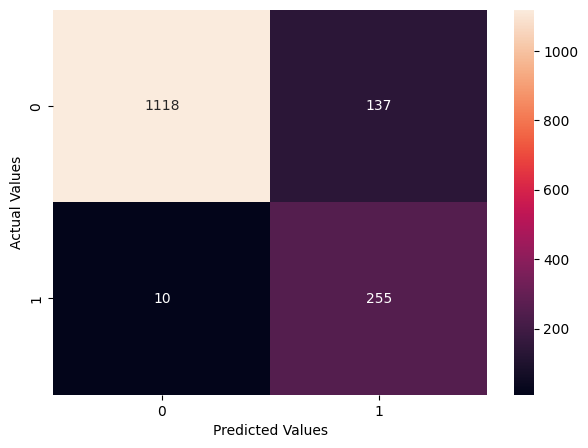

```python
display_confusion_matrix(model_oversampled_data_tuned, X_test, y_test)
```

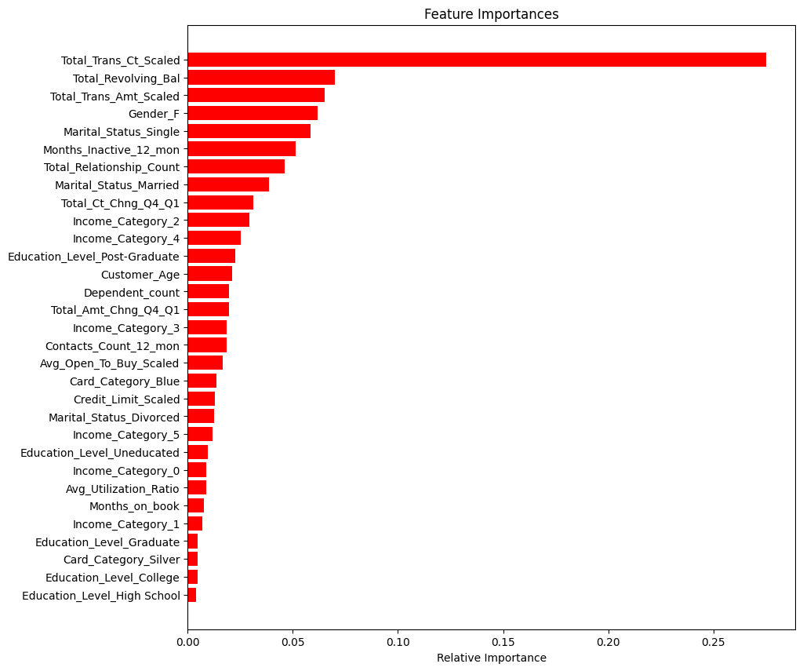

```python
display_importance_of_features(model_oversampled_data_tuned, X_test.columns)
```

#### Final Model Performance

**High Recall on Test Data:**

Recall: 96.2% – The model successfully identifies churners in the test data, meeting the primary goal of capturing potential churners.

**Balanced Performance on Training and Test Sets:**

**Precision Trade-Off:**

Precision on the test set is 65.05%, which is lower than recall but expected in this setup due to the focus on identifying as many churners as possible. Some false positives (non-churners flagged as churners) are expected.

**F1-Score:**

77.6% This score balances the model’s recall and precision and overall effectiveness.

**Final Points and Recommendations**

- Strength in Identifying Churners: With high recall on the test data, this model is highly suitable for scenarios where the cost of missing a churner is much greater than the cost of following up on non-churners.
- Plan and manage False Positives as the model may produce some false positives.

## Business Insights and Conclusions

1. Increase Engagement with Low-Activity Customers: Transaction count and transaction amount are the top indicators. Implement targeted engagement programs, such as personalized offers or loyalty rewards.
2. Address Financial Situation/Strain for High-Revolving Balance Customers. Customers with high revolving balances are more likely to churn. The business can offer financial counseling, lower-interest balance transfer options, or customized payment plans.
3. The bank may focus Retention Efforts on Customers with Lower Product Relationship groups. Cross-sell additional products, or offer bundled packages benefits.
4. Re-Engage Inactive Customers with higher months of inactivity. Focus on inactive customers to reconnect through product updates or special incentives to restart usage.
5. Create Special Programs for High-Risk Profiles. Identify customers who show declining transactions reach out to them with special offers.

These strategies can help improve customer loyalty, and reduce churn.